# Kolleg Europa - Social Network Analysis

Datenauswertung Reisediplomatie-Netzwerk

Stefan Haussner

08.07.2019

```r
load("C:/OwnCloud/SH/Workshops_Talks/KollegEuropa_Studienstiftung_Netzwerkanalyse_Prag/R/network_analysis_KollegEuropa/data/data_preprocessed.Rdata")
#load("D:/KollegEuropa_Studienstiftung_Netzwerkanalyse_Prag/R/network_analysis_KollegEuropa/data/data_preprocessed.Rdata")
```

Grundsätzlich sieht das Reisediplomatie-Netzwerk bereits so aus. Limitations bzw. offene Fragen finden sich im `script_datawrangling.Rmd`. Größere Abbildungen liegen in “outputs”.

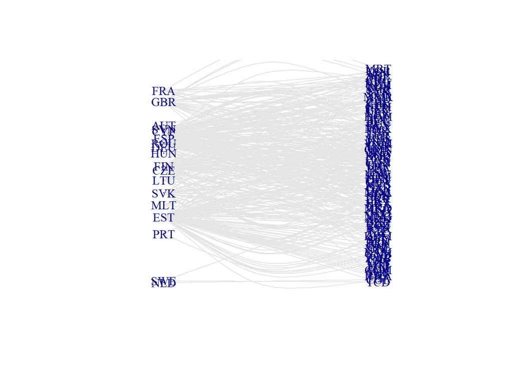

```r
LO <- layout_as_bipartite(rd_igraph)

# Variante 1:


plot.igraph(rd_igraph,
            vertex.color = V(rd_igraph)$type,
            layout=LO[,2:1],
            vertex.size = 0,
            #vertex.label.color = V(rd_igraph)$color,
            edge.color = "grey90")
```

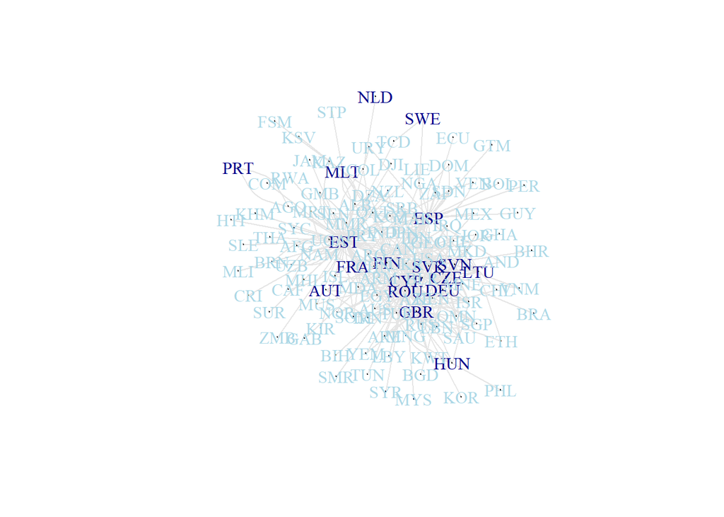

```r
# Variante 2:

plot.igraph(rd_igraph,
            vertex.color = V(rd_igraph)$type,
            layout=layout_with_lgl,
            vertex.size = 0,
            vertex.label.color = V(rd_igraph)$color,
            edge.color = "grey90")
```

```r
#rd_igraph <- subgraph.edges(rd_igraph, eids = which(E(rd_igraph)$year == 2019))
```

# Analyse des Two-Mode-Netzwerks

Es gibt verschiedene Ansätze für die Analyse von Zugehörigkeitsdaten, ohne die Umwandlung in `Co-Affiliation-Netze` (Projections). Da Zugehörigkeitsgraphen auch Graphen sind, liegt der naheliegende Ansatz darin, einfach alle Standardalgorithmen und -techniken des Netzwerkanalyse-Toolkits zu verwenden, die für normale Netze im Allgemeinen gelten.

Dabei gehen wir entweder davon aus, dass die spezielle Natur von Affiliationsnetzen die Techniken nicht beeinflusst, oder wir können vorgeben, dass Bindungen innerhalb von Knotensätzen aufgetreten sein könnten und einfach nicht aufgetreten sind. Dieser Ansatz funktioniert für eine kleine Klasse von Methoden, jedoch keineswegs für alle.

Ein alternativer Ansatz besteht darin, neue Metriken und Algorithmen zu entwickeln, die speziell für den TwoMode-Fall designed wurden. Das hört sich nach viel mehr Arbeit an, aber in der Praxis ist es oft möglich, Metriken anzupassen, die für allgemeine Diagramme ausgelegt sind, indem einfach eine entsprechende Post-hoc-Normalisierung angewendet wird. Besonders bei Zentralitätsmaßen ist das meist der bessere Weg.[^1]

Im Degree-Fall ist es nicht sinnvoll, den einfachen Grad (Anzahl aller Verbindungen des Knotens) zu zählen und daraus die Dichte zu errechnen. Denn zwischen den Knoten einer Gruppe können ja gar keine Verbindungen bestehen. Eine sinnvolle Änderung ist es also, wenn die Dichte auf der Grundlage der Verbindungen besteht, die der Knoten mit der Gruppe des anderen Typs aufweist.

```r
density_bipartite <- function(graph) {
  if (is.directed(graph)) {
    ecount(graph) / sum(V(graph)$type) / sum(!V(graph)$type) / 2.0}
  else {
    ecount(graph) / sum(V(graph)$type) / sum(!V(graph)$type)
  }
}

edge_density(rd_igraph)
```

```
## [1] 0.044
```

```r
density_bipartite(rd_igraph)
```

```
## [1] 0.1770509
```

Auch bei der Closeness-Zentralität bietet sich eine Anpassung an. Diese wurde an dieser Stelle in ein externes Script ausgelagert (`bipartite_closeness_centrality.R`) und kann dort bei Bedarf nachvollzogen werden.

> Erinnerung `Closeness`: mittlere Entfernung von einem Scheitelpunkt zu anderen Scheitelpunkten.

```r
source("bipartite_closeness_centrality.R")

#bipartite_closeness_centrality(rd_igraph)

bipartite_closeness_centrality(rd_igraph) %>% unlist() %>% unname() %>% round(3) %>% tbl_df() %>%
  mutate(name = V(rd_igraph)$name,
         type = case_when(V(rd_igraph)$type == TRUE ~ "eu",
                          TRUE ~ "non-eu")) %>%
  select(name, closeness_centrality = value, type) %>%
  arrange(type, -closeness_centrality) %>%
  datatable(options = list(pageLength = 23))
```

|  | name | closeness_centrality | type |
| --- | --- | --- | --- |
| 1 | DEU | 0.566 | eu |
| 2 | CYP | 0.507 | eu |
| 3 | SVN | 0.475 | eu |
| 4 | GBR | 0.475 | eu |
| 5 | EST | 0.453 | eu |
| 6 | PRT | 0.445 | eu |
| 7 | HUN | 0.434 | eu |
| 8 | ESP | 0.423 | eu |
| 9 | SWE | 0.421 | eu |
| 10 | SVK | 0.411 | eu |

[output cut: 115 more lines]

Gleiches gilt für die Betweenness-Zentralität.

> Erinnerung `Betweenness`: Ausmaß, in dem ein Knoten auf Pfaden zwischen anderen Knoten liegt.

```r
source("bipartite_betweenness_centrality.R")

#bipartite_betweenness_centrality(rd_igraph)

bipartite_betweenness_centrality(rd_igraph) %>% unlist() %>% unname() %>% round(3) %>% tbl_df %>%
  mutate(name = V(rd_igraph)$name,
         type = case_when(V(rd_igraph)$type == TRUE ~ "eu",
                          TRUE ~ "non-eu")) %>%
  select(name, betweenness_centrality = value, type) %>%
  arrange(type, -betweenness_centrality) %>%
  datatable(options = list(pageLength = 23))
```

|  | name | betweenness_centrality | type |
| --- | --- | --- | --- |
| 1 | DEU | 0.473 | eu |
| 2 | SVN | 0.2 | eu |
| 3 | GBR | 0.164 | eu |
| 4 | EST | 0.117 | eu |
| 5 | PRT | 0.091 | eu |
| 6 | HUN | 0.091 | eu |
| 7 | CYP | 0.078 | eu |
| 8 | ESP | 0.054 | eu |
| 9 | LTU | 0.049 | eu |
| 10 | SWE | 0.048 | eu |

[output cut: 115 more lines]

# Analyse der One-Mode-Projektionen

```r
rd_projection <- bipartite.projection(rd_igraph)
rd_projection
```

```
## $proj1
## IGRAPH fdb7f11 UNW- 107 2771 --
## + attr: name (v/c), color (v/c), weight (e/n)
## + edges from fdb7f11 (vertex names):
##  [1] USA--RUS USA--ISR USA--CAN USA--JOR USA--TUR USA--MAR USA--BLR
##  [8] USA--BGD USA--CHN USA--IDN USA--ISL USA--UKR USA--GEO USA--DZA
## [15] USA--ARM USA--AZE USA--SEN USA--MKD USA--MLI USA--SRB USA--SOM
## [22] USA--QAT USA--UGA USA--AFG USA--ALB USA--SLE USA--MDA USA--MNE
## [29] USA--GMB USA--MUS USA--NAM USA--ZMB USA--SYC USA--MHL USA--CAF
## [36] USA--KIR USA--BRN USA--KHM USA--MNG USA--THA USA--KAZ USA--AGO
## [43] USA--COL USA--CRI USA--PRY USA--NZL USA--UZB USA--LIE USA--HTI
## [50] USA--JAM USA--SDN USA--COM USA--URY USA--SUR USA--TCD USA--KGZ
## + ... omitted several edges
##
## $proj2
## IGRAPH fdb7f11 UNW- 18 98 --
## + attr: name (v/c), color (v/c), weight (e/n)
## + edges from fdb7f11 (vertex names):
##  [1] DEU--EST DEU--FIN DEU--FRA DEU--LTU DEU--ROU DEU--SVK DEU--SVN
##  [8] DEU--CZE DEU--GBR DEU--HUN DEU--CYP DEU--ESP DEU--MLT EST--FIN
## [15] EST--FRA EST--LTU EST--ROU EST--SVK EST--SVN EST--CZE EST--GBR
## [22] EST--AUT EST--ESP EST--CYP EST--HUN EST--MLT EST--PRT EST--NLD
## [29] EST--SWE FIN--FRA FIN--LTU FIN--ROU FIN--SVK FIN--SVN FIN--CZE
## [36] FIN--GBR FIN--MLT FIN--ESP FIN--CYP FIN--HUN FIN--AUT FIN--SWE
## [43] FIN--PRT FRA--LTU FRA--ROU FRA--SVK FRA--SVN FRA--CZE FRA--GBR
## [50] FRA--HUN FRA--CYP FRA--ESP FRA--AUT LTU--ROU LTU--SVK LTU--SVN
## + ... omitted several edges
```

```r
rd_hosts <- rd_projection$proj1
rd_eu28 <- rd_projection$proj2

rd_eu28
```

```
## IGRAPH fdb7f11 UNW- 18 98 --
## + attr: name (v/c), color (v/c), weight (e/n)
## + edges from fdb7f11 (vertex names):
##  [1] DEU--EST DEU--FIN DEU--FRA DEU--LTU DEU--ROU DEU--SVK DEU--SVN
##  [8] DEU--CZE DEU--GBR DEU--HUN DEU--CYP DEU--ESP DEU--MLT EST--FIN
## [15] EST--FRA EST--LTU EST--ROU EST--SVK EST--SVN EST--CZE EST--GBR
## [22] EST--AUT EST--ESP EST--CYP EST--HUN EST--MLT EST--PRT EST--NLD
## [29] EST--SWE FIN--FRA FIN--LTU FIN--ROU FIN--SVK FIN--SVN FIN--CZE
## [36] FIN--GBR FIN--MLT FIN--ESP FIN--CYP FIN--HUN FIN--AUT FIN--SWE
## [43] FIN--PRT FRA--LTU FRA--ROU FRA--SVK FRA--SVN FRA--CZE FRA--GBR
## [50] FRA--HUN FRA--CYP FRA--ESP FRA--AUT LTU--ROU LTU--SVK LTU--SVN
## + ... omitted several edges
```

```r
E(rd_eu28)$weight
```

```
##  [1]  7 13  9 25 17 18  9  9 12  5  9  6  1 16  3 10 15 25  3 18 10  2 17
## [24] 17  3  3  2  2  1  5 11  9  7  5 10 12  5 21 24  3  2  1  2  5  4  3
## [47]  2  3  8  3  3  5  1 16 17  5 11 13  2  9  4  1  3  2  1  2  1  3  4
## [70] 17  5 13 15  7 16  1  1  5 20 10  6 13  3  4  6  1  8  5  4 10 17  2
## [93] 10 16  3  4  4 11
```

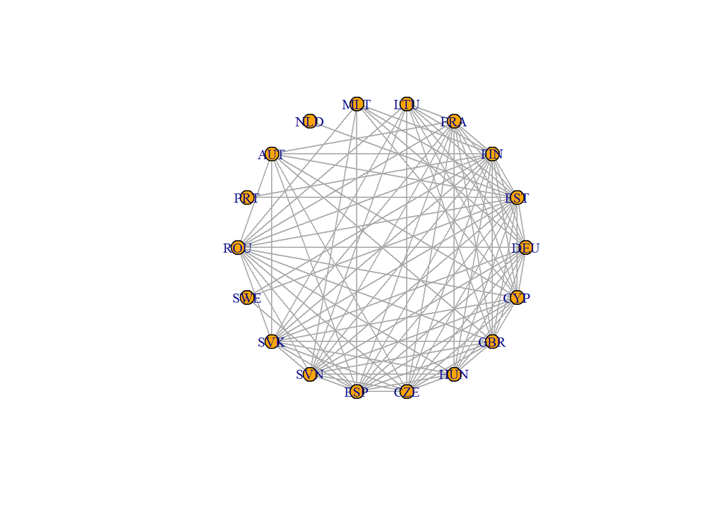

```r
plot.igraph(rd_eu28,
            vertex.label.cex = 0.8,
            vertex.size = 10,
            vertex.color = "orange",
            layout = layout_in_circle)
```

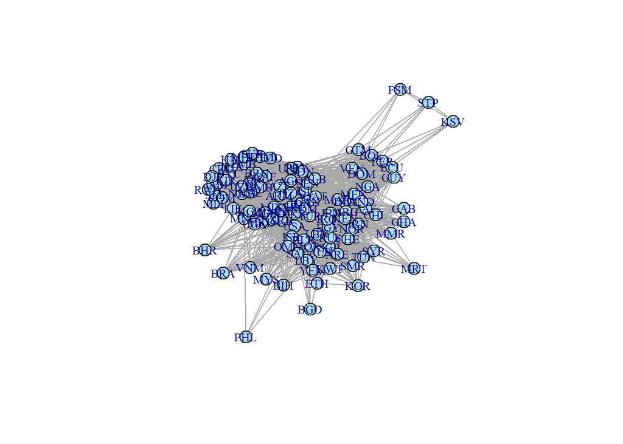

```r
plot.igraph(rd_hosts,
            vertex.label.cex = 0.8,
            vertex.size = 10,
            vertex.color = "lightblue")
```

# Analyse des EU28-Netzwerks

Das EU28-Netzwerk ist ein `Co-occurence-Netzwerk` (One-Mode-Projektion des ursprünglichen Reisediplomatienetzwerks). Zwei Länder der EU28 haben dann eine Verbindung, wenn sie das gleiche Gastland besucht haben. Das Netzwerk ist ein ungerichtetes Netzwerk.

## Distances and paths

```r
mean_distance(rd_eu28, directed=FALSE)
```

```
## [1] 1.359477
```

## edge density

```r
edge_density(rd_eu28)
```

```
## [1] 0.6405229
```

## Welche Länder sind im Netzwerk besonders auffallend?

Es ist intuitiv sinnvoll, dass ein Netzwerkmitglied, das mit vielen anderen Mitgliedern des Netzwerks verbunden ist, eine herausragende Position einnimmt. Für nicht gerichtete Netzwerke sprechen wir von Akteuren mit einer hohen Zentralität. Es gibt jedoch eine Reihe von Möglichkeiten, diese Art der Zentralität zu operationalisieren. Tatsächlich stehen in der Sozialen Netzwerkanalyse Dutzende von Zentralitätsstatistiken zur Verfügung.

### Degree centrality

> Erinnerung degree: Anzahl, wie viele Nachbarn ein Knoten hat.

```r
degree(rd_eu28)
```

```
## DEU EST FIN FRA LTU MLT NLD AUT PRT ROU SWE SVK SVN ESP CZE HUN GBR CYP
##  13  17  16  13  10   7   1   9   2  14   3  13  13  14  13  11  13  14
```

```r
r_degree <- degree(rd_eu28)

data.frame(r_degree) %>%
  datatable(options = list(pageLength = 23))
```

|  | r_degree |
| --- | --- |
| DEU | 13 |
| EST | 17 |
| FIN | 16 |
| FRA | 13 |
| LTU | 10 |
| MLT | 7 |
| NLD | 1 |
| AUT | 9 |
| PRT | 2 |
| ROU | 14 |

[output cut: 8 more lines]

### Closeness Centrality

> Erinnerung closeness: mittlere Entfernung von einem Scheitelpunkt zu anderen Scheitelpunkten

```r
r_closeness <- closeness(rd_eu28, weights = E(rd_eu28)$weight)
data.frame(r_closeness) %>%
  round(5) %>%
  datatable(options = list(pageLength = 23))
```

|  | r_closeness |
| --- | --- |
| DEU | 0.01176 |
| EST | 0.01786 |
| FIN | 0.01562 |
| FRA | 0.01724 |
| LTU | 0.0082 |
| MLT | 0.01449 |
| NLD | 0.01136 |
| AUT | 0.01887 |
| PRT | 0.01163 |
| ROU | 0.01471 |

[output cut: 8 more lines]

### Betweenness

> Erinnerung betweenness: Ausmaß, in dem ein Knoten auf Pfaden zwischen anderen Knoten liegt.

```r
r_betweenness <- igraph::betweenness(rd_eu28, weights = E(rd_eu28)$weight)
data.frame(r_betweenness) %>%
  round(5) %>%
  datatable(options = list(pageLength = 23))
```

|  | r_betweenness |
| --- | --- |
| DEU | 0 |
| EST | 30.7369 |
| FIN | 7.11429 |
| FRA | 17.40476 |
| LTU | 0 |
| MLT | 16.33333 |
| NLD | 0 |
| AUT | 50.87619 |
| PRT | 0 |
| ROU | 1 |

[output cut: 8 more lines]

### Eigenvector-Centrality

> Erinnerung eigenvector: Ein Knoten ist wichtig, wenn er mit anderen wichtigen Knoten verbunden ist.

```r
r_eigen <- eigen_centrality(rd_eu28, weights = E(rd_eu28)$weight)
data.frame(r_eigen$vector) %>%
  round(5) %>%
  datatable(options = list(pageLength = 23))
```

|  | r_eigen.vector |
| --- | --- |
| DEU | 0.90042 |
| EST | 1 |
| FIN | 0.91946 |
| FRA | 0.35164 |
| LTU | 0.80976 |
| MLT | 0.17744 |
| NLD | 0.01618 |
| AUT | 0.12586 |
| PRT | 0.03105 |
| ROU | 0.94037 |

[output cut: 8 more lines]

Alle Ergebnisse gesammelt und in sortierbarer Tabelle:

```r
results_df <- data.frame(r_degree,r_closeness, r_betweenness, r_eigen$vector) %>%
  rownames_to_column() %>% tbl_df() %>%
  mutate_if(is.numeric, round, 4) %>%
  arrange(rowname)

datatable(results_df, options = list(pageLength = 23))
```

|  | rowname | r_degree | r_closeness | r_betweenness | r_eigen.vector |
| --- | --- | --- | --- | --- | --- |
| 1 | AUT | 9 | 0.0189 | 50.8762 | 0.1259 |
| 2 | CYP | 14 | 0.0108 | 8.5603 | 0.9525 |
| 3 | CZE | 13 | 0.0143 | 0 | 0.8564 |
| 4 | DEU | 13 | 0.0118 | 0 | 0.9004 |
| 5 | ESP | 14 | 0.0156 | 4.8155 | 0.7116 |
| 6 | EST | 17 | 0.0179 | 30.7369 | 1 |
| 7 | FIN | 16 | 0.0156 | 7.1143 | 0.9195 |
| 8 | FRA | 13 | 0.0172 | 17.4048 | 0.3516 |
| 9 | GBR | 13 | 0.0102 | 0 | 0.8012 |
| 10 | HUN | 11 | 0.0185 | 20.5012 | 0.2156 |

[output cut: 8 more lines]

## Subgroups and communities

### Transitivität

> Die Transitivität misst die Wahrscheinlichkeit, dass die benachbarten Knoten eines Knoten miteinander verbunden sind. Dies wird manchmal auch als Clustering-Koeffizient bezeichnet.

```r
transitivity(rd_eu28)
```

```
## [1] 0.8445596
```

### Größte Clique

Macht in diesem Falle auch wenig Sinn.

```r
#cliques(rd_eu28) # list of cliques
largest_cliques(rd_eu28)
```

```
## [[1]]
## + 12/18 vertices, named, from fdb7f11:
##  [1] EST FIN ROU CYP DEU SVN FRA SVK CZE GBR ESP HUN
```

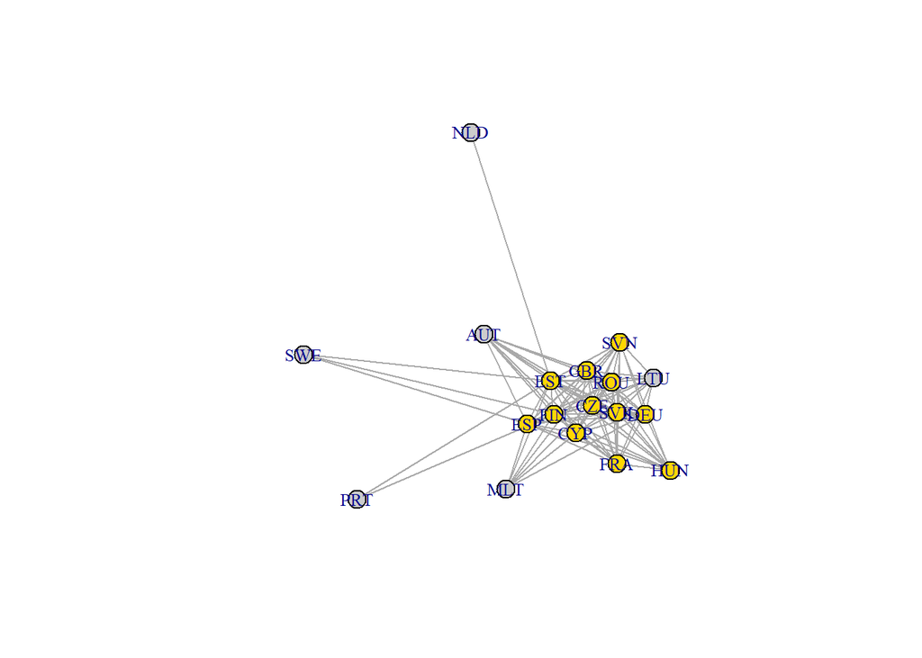

```r
vcol <- rep("grey80", vcount(rd_eu28))
vcol[unlist(largest_cliques(rd_eu28))] <- "gold"
plot(as.undirected(rd_eu28), vertex.label=V(rd_eu28)$name, vertex.color=vcol,
     vertex.label.cex = 0.8,
     vertex.size = 10)
```

### Community detection

```r
ceb <- cluster_edge_betweenness(rd_eu28, weights = E(rd_eu28)$weight)
```

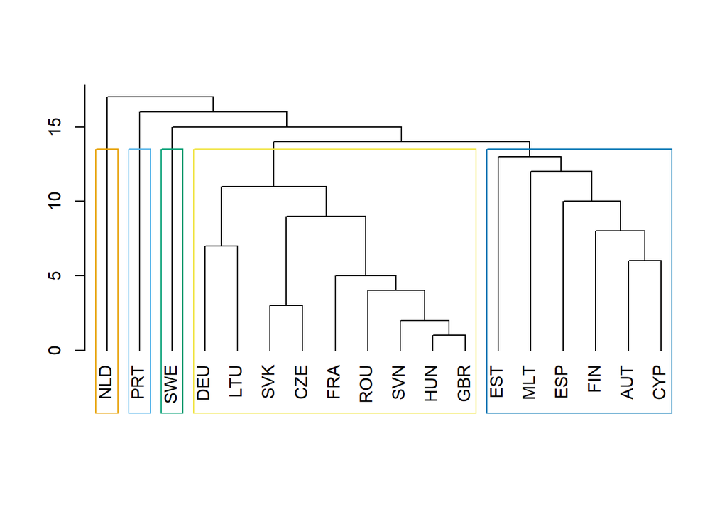

```r
cle <- cluster_leading_eigen(rd_eu28, weights = E(rd_eu28)$weight)

cop <- cluster_optimal(rd_eu28, weights = E(rd_eu28)$weight)

cluster_walktrap(rd_eu28, weights = E(rd_eu28)$weight) %>% dendPlot(mode = "hclust")
```

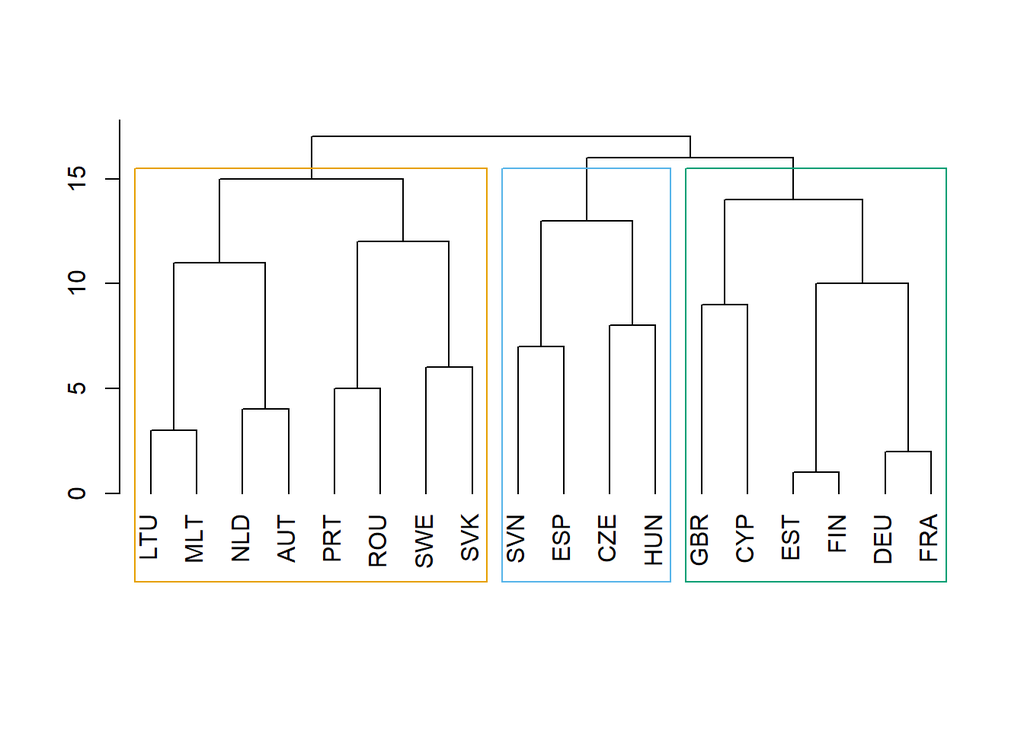

```r
#dendPlot(ceb, mode="hclust")
dendPlot(cle, mode="hclust")
```

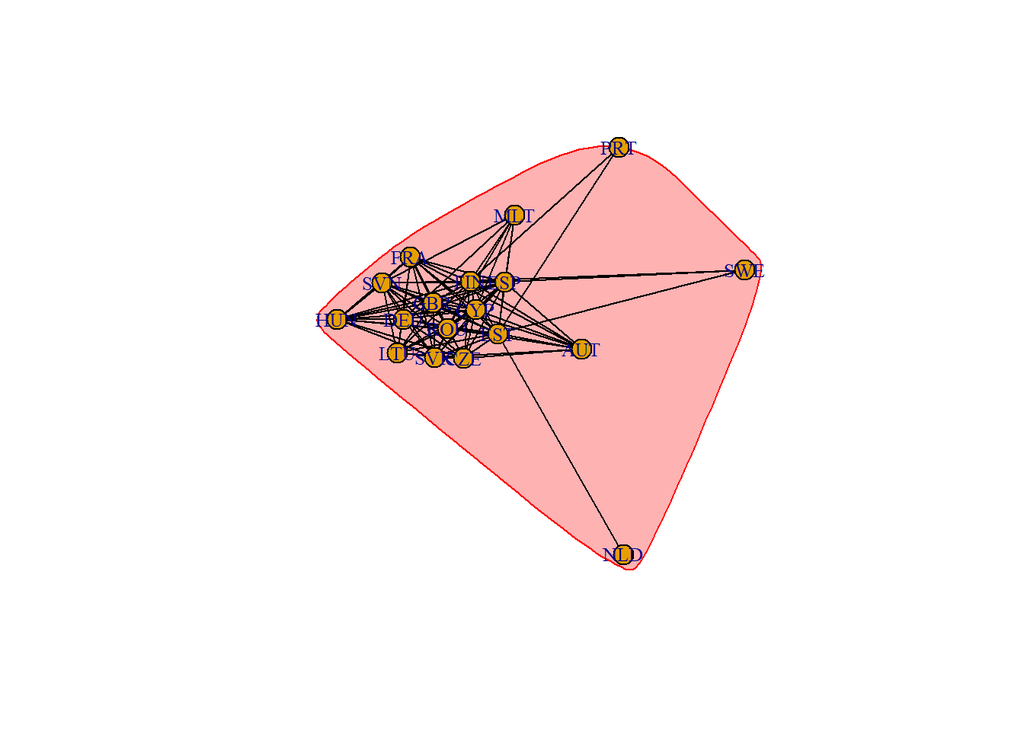

```r
plot(ceb,rd_eu28,
     vertex.label.cex = 0.8,
     vertex.size = 10)
```

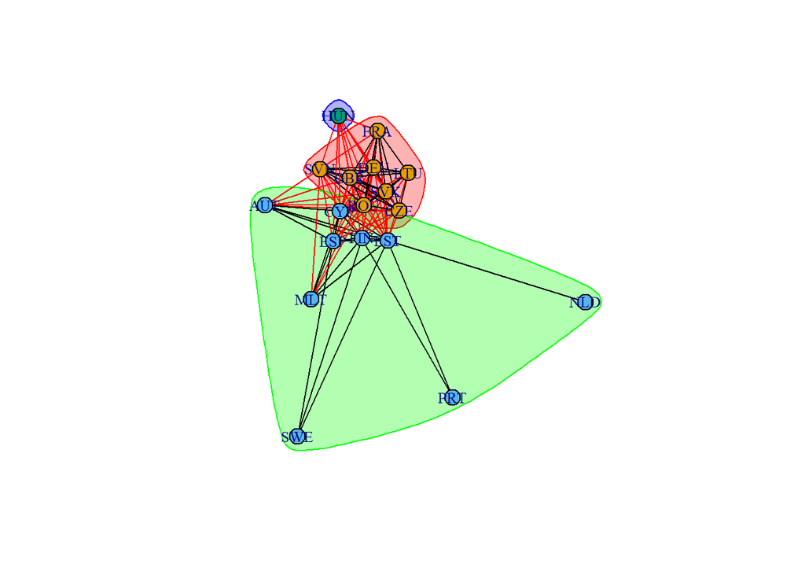

```r
plot(cle,rd_eu28,
     vertex.label.cex = 0.8,
     vertex.size = 10)
```

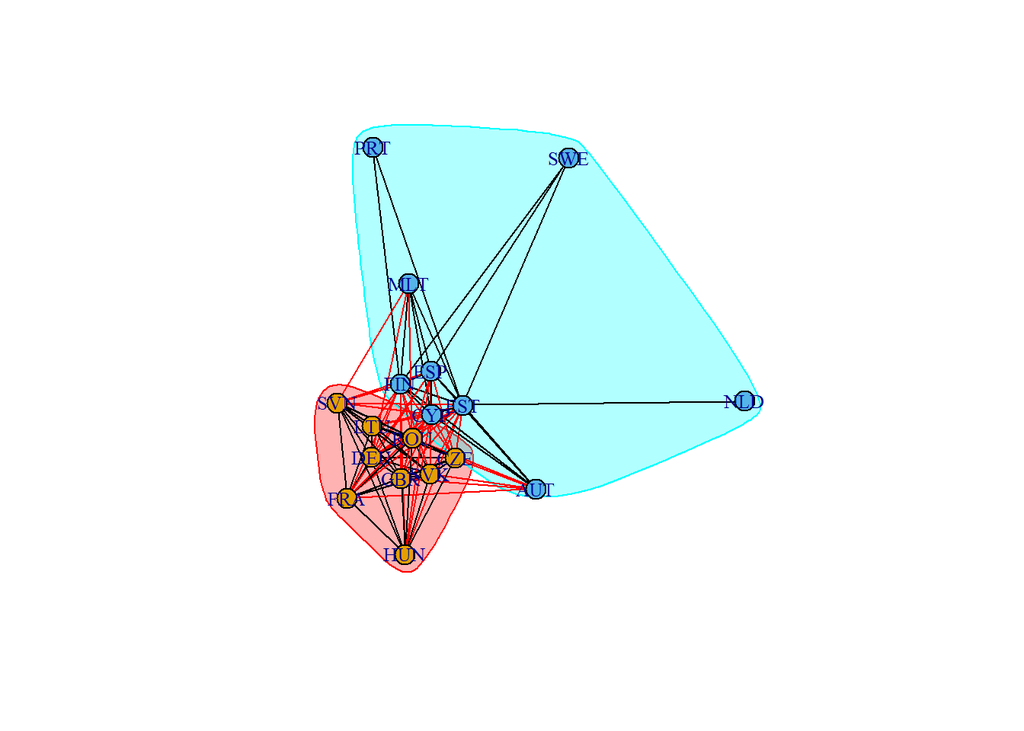

```r
plot(cop,rd_eu28,
     vertex.label.cex = 0.8,
     vertex.size = 10)
```